# ¿Está relacionada la victimización con la percepción de inseguridad?

Constanza Acevedo

22-11-2021

##### Facultad de Ciencias Sociales

##### Departamento de Política y Gobierno

##### Carrera de Ciencia Política y Relaciones Internacionales

##### Profesora: Valentina Andrade

##### Ayudantes: Dafne Jaime y Nicolás Godoy

### I.- Introducción:

En Latinoamérica uno de los principales problemas detectados por la opinión pública está configurado por la delincuencia, la violencia y las pandillas (Dammert & Lagos, 2012). En 2011, según el latinobarómetro, la seguridad pública superó al desempleo como la principal preocupación para los latinoamericanos (De Lima & de Paula, 2013). De esta forma, la inseguridad asociada a la criminalidad se ha convertido en un punto importante dentro de las agendas de gobierno.

Entre los factores que influyen en la percepción de seguridad en la ciudadanía y en su dimensión subjetiva (el miedo), se encuentran los factores individuales, físico-territoriales, socio-barriales, institucionales, culturales y, delictuales (Subsecretaría de prevención del delito, 2020).

En este sentido, el nivel local (municipios) se ha convertido en un ámbito decisivo para la implementación de intervenciones más efectivas, dada la proximidad con la ciudadanía, la mayor visibilidad de los factores que inciden en los problemas abordados y la presión que pueden ejercer las poblaciones directamente afectadas sobre los municipios” (Centro de Seguridad Urbana UAH, 2018).

De esta forma, este estudio estará enfocado en un nivel comunal considerando a aquellas comunas ubicadas en las regiones de Atacama, O’Higgins, Biobío, la Araucanía y Metropolitana, con el fin de identificar qué factores inciden en el aumento de la percepción de inseguridad en la ciudadanía.

### II.- Desarrollo:

La inseguridad asociada a la criminalidad es un fenómeno complejo de resolver y de investigar, sin realizar un análisis en profundidad se tiende a pensar que está relacionado con el aumento de los índices de criminalidad. No obstante, diversas investigaciones han desmontado esta suposición.

Tabla N°1. Matriz de Correlación

|  | Victimización | Percepción de inseguridad |
| --- | --- | --- |
| Victimización |  |  |
| Percepción de inseguridad | -0.045*** |  |
| Computed correlation used pearson-method with listwise-deletion. |  |  |

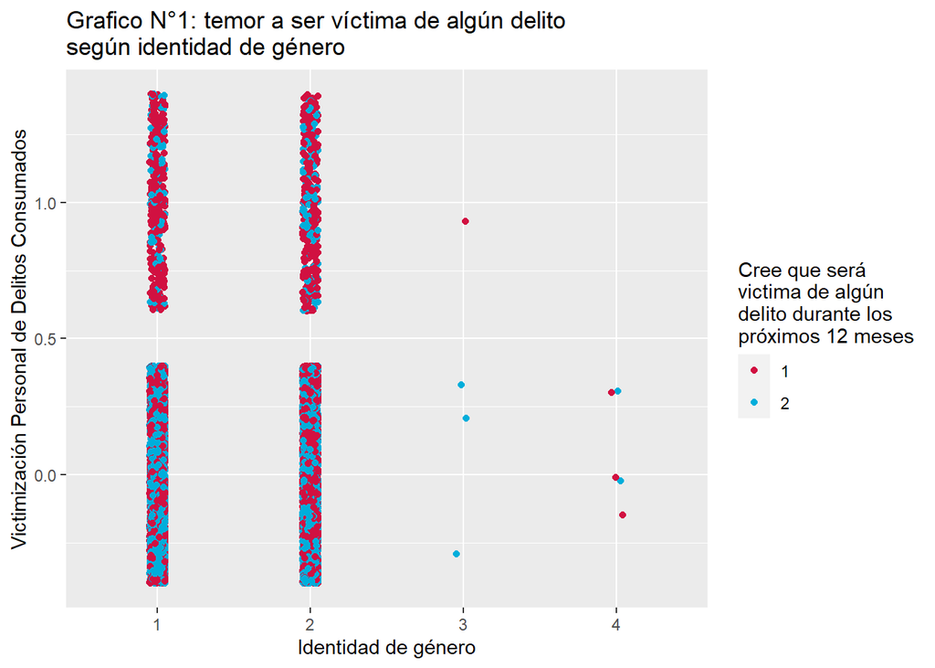

Siguiendo en la línea de lo mencionado por la Subsecretaria de prevención del delito, los factores individuales, tales como el sexo o la edad de las personas, son algunas de las variables que influyen en la percepción de seguridad. Esto se explica por la vulnerabilidad de ciertos estratos etarios (adultos mayores, y NNA), y por la doble victimización que viven las mujeres y disidencias.

Modelo 1

Modelo 2

Predictores

EstimaciÃ³n

(Intercepto)

0.964 ***

1.061 ***

VictimizaciÃ³n Personal de  
Delitos Consumados

-0.062 **

-0.058 **

Cree que será victima de  
algún delito durante los  
próximos 12 meses

0.204 ***

0.205 ***

Factor de expansiÃ³n para  
personas a nivel regional

*Reference*

*Reference*

Adulto

*Reference*

*Reference*

Adulto mayor

0.035 **

Joven

0.157 ***

Masculino

*Reference*

*Reference*

Femenino

-0.093 ***

Trans

-0.437 *

Otro

-0.070

No sabe

*Reference*

*Reference*

Observations

9673

9671

R<sup>2</sup> / R<sup>2</sup> adjusted

0.056 / 0.055

0.048 / 0.047

- p<0.05 ** p<0.01 *** p<0.001

De esta forma, el gráfico N°2, nos muestra que, a nivel comunal, la percepción de aumento de la delincuencia es mayormente compartida entre las mujeres con un 57.1% versus un 42.8% de los hombres.

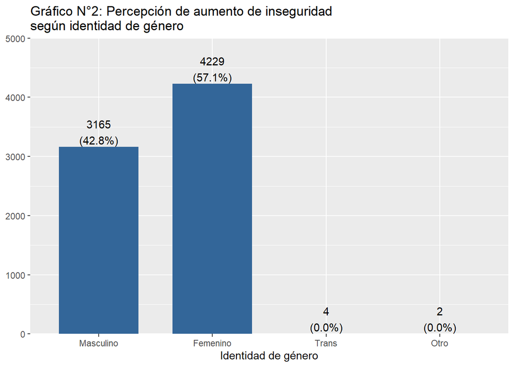

La ENUSC aún posee falencias en identificar comportamientos que causen inseguridad a las mujeres y disidencias. En este sentido, no considera crímenes de odio, acoso callejero o violencia intrafamiliar.

### III.- Conclusiones:

Según los resultados de la ENUSC 2020, tiene como conclusión una caída en la tasa de victimización. Esto no coincide con los datos obtenidos en la percepción de aumento de la delincuencia, lo que viene a confirmar que son fenómenos que no necesariamente van de la mano.

La percepción de inseguridad es la consecuencia de diversos factores sociales e individuales, tales como: altas tasas de desigualdad, la desconfianza en las instituciones que garantizan el orden, percepción de abandono estatal, deterioro del tejido social, entre otros.

Por otro lado, las personas que son víctimas de algún delito suelen estar más alertas que aquellos que no. Independiente de si los índices delictuales van a la baja, los altos índices de percepción de inseguridad se siguen manteniendo en el tiempo. Esto se explica por la demora en recuperar la tranquilidad y la normalidad.

El abordaje del fenómeno de la delincuencia y los problemas asociados a esta involucra particularidades territoriales o contextuales, visiones conceptuales contrapuestas donde se cruzan fundamentos valóricos y políticos. No obstante, existe consenso en la multicausalidad del problema de la delincuencia, lo que requiere el desarrollo de estrategias integrales e intersectoriales que permitan el abordaje de sus causas, manifestaciones y consecuencias.

### IV.- Referencias

Centro de Seguridad Urbana UAH. (2018, abril). Informe Final: «Levantamiento de Línea Base del estado de gestión municipal en seguridad»" (N.o 1). Centro de Seguridad Urbana, UAH Facultad de Derecho. http://cead.spd.gov.cl/?wpdmpro=estudio-linea-base-gestion-local&wpdmdl=3002&

Dammert, L., & Lagos, M. (2012, mayo). La seguridad ciudadana: el problema principal de América Latina. FlacsoAndes. https://biblio.flacsoandes.edu.ec/libros/139282-opac

De Lima, R. S., & de Paula, L. (2013). Seguridad pública y reducción de crímenes violentos en Brasil: logros en gestión y cambios institucionales. En ¿A dónde vamos? (1.a ed., pp. 153–171). Woodrow Wilson International Center for Scholars & CASEDE.

Subsecretaría de Prevención del Delito. (2020). MINUTA ESTUDIO: FACTORES DETERMINANTES EN LA PERCEPCIÓN DE INSEGURIDAD. Portal CEAD. http://cead.spd.gov.cl/estudios-y-encuestas/